# Análisis de factores que influyen en el costo de los seguros médicos (2020–2025)

Alexis Medrano Rivera

2025-07-19

```r
knitr::opts_chunk$set(echo = TRUE, warning = FALSE, message = FALSE)
library(tidyverse)
```

```r
library(lubridate)
library(ggplot2)
library(lmtest)
library(car)
library(sandwich)
library(MASS)
```

## Introducción

Factores como la edad, el índice de masa corporal (IMC), el número de hijos, el hábito de fumar y la región geográfica de residencia pueden tener un impacto significativo o moderado en el precio de las pólizas de seguro médico. Este es un tema crucial tanto para las compañias aseguradoras como para quienes diseñan productos de seguros. Por tal motivo este proyecto busca mejorar la precisión en la estimación de precios y ajustar el perfil de riesgo para diseñar productos más eficientes.

El presente proyecto fue inspirado en el dataset **“Medical Cost Personal Datasets”** de Kaggle, el cual fue utilizado como base para generar un conjunto de datos artificial con 500 observaciones comprendidas entre enero de 2020 y julio de 2025, con el objetivo de recrear circunstancias reales del mercado. A partir de este dataset, se ajustó un modelo de regresión múltiple, se validaron sus supuestos y se emitieron recomendaciones y conclusiones orientadas a la fijación adecuada de precios.

## Data

- **Origen:** Simulado *ad hoc* para fines académicos (semilla fija para reproducibilidad).
- **Rango temporal:** 01‑ene‑2020 — 19‑jul‑2025.
- **Registros:** 500 observaciones a nivel individual.
- **Variables:**
  - `date`: Fecha de emisión
  - `age`: Edad en años
  - `sex`: Sexo (`male` / `female`)
  - `bmi`: Índice de masa corporal
  - `children`: Número de dependientes
  - `smoker`: Fumador (`yes` / `no`)
  - `region`: Región (`northeast`, `northwest`, `southeast`, `southwest`)
  - `charges`: Costo de la póliza en USD

**Nota:** Este dataset es completamente simulado y no representa datos reales.

## Metodología

En este apartado se describen con detalle los pasos seguidos para explorar, preparar, modelar y validar los datos, así como la forma de interpretar los resultados obtenidos.

### 1 Exploratory Data Analysis (EDA)

Primero se cargan los datos y se realiza un análisis exploratorio para familiarizarse con la distribución y las relaciones de las variables.

```r
# cargar data
data <- read.csv("C:/Users/Usuario/Downloads/mi_dataset_seguros.csv")
head(data)
```

```
##         date age    sex  bmi children smoker    region charges
## 1 2023-01-31  20 female 36.5        2     no southwest 3189.38
## 2 2023-12-30  35 female 27.6        4     no southwest 4793.51
## 3 2022-05-10  42   male 20.1        3     no southeast  100.00
## 4 2023-07-18  59 female 34.2        0     no southeast  172.07
## 5 2023-02-04  48 female 31.4        3     no southeast 4060.18
## 6 2022-12-31  20   male 40.9        2     no northeast 2933.62
```

```r
# Vista rápida de las variables
str(data)        # Estructura de las variables
```

```
## 'data.frame':    500 obs. of  8 variables:
##  $ date    : chr  "2023-01-31" "2023-12-30" "2022-05-10" "2023-07-18" ...
##  $ age     : int  20 35 42 59 48 20 57 63 41 49 ...
##  $ sex     : chr  "female" "female" "male" "female" ...
##  $ bmi     : num  36.5 27.6 20.1 34.2 31.4 40.9 20.8 46.8 39.6 29.9 ...
##  $ children: int  2 4 3 0 3 2 2 3 4 4 ...
##  $ smoker  : chr  "no" "no" "no" "no" ...
##  $ region  : chr  "southwest" "southwest" "southeast" "southeast" ...
##  $ charges : num  3189 4794 100 172 4060 ...
```

```r
summary(data)    # Estadísticas descriptivas básicas
```

```
##      date                age            sex                 bmi
##  Length:500         Min.   :18.00   Length:500         Min.   :13.30
##  Class :character   1st Qu.:29.00   Class :character   1st Qu.:26.40
##  Mode  :character   Median :41.00   Mode  :character   Median :30.50
##                     Mean   :40.68                      Mean   :30.79
##                     3rd Qu.:52.00                      3rd Qu.:35.20
##                     Max.   :64.00                      Max.   :49.00
##     children        smoker             region             charges
##  Min.   :0.000   Length:500         Length:500         Min.   :  100
##  1st Qu.:1.000   Class :character   Class :character   1st Qu.:  111
##  Median :2.000   Mode  :character   Mode  :character   Median : 1832
##  Mean   :2.066                                         Mean   : 3485
##  3rd Qu.:3.000                                         3rd Qu.: 4171
##  Max.   :4.000                                         Max.   :16818
```

```r
colSums(is.na(data)) # Buscar datos faltantes
```

```
##     date      age      sex      bmi children   smoker   region  charges
##        0        0        0        0        0        0        0        0
```

#### 1.1 Distribuciones univariadas

Histogramas de `age`, `bmi` y `charges` para detectar sesgos, colas o valores atípicos:

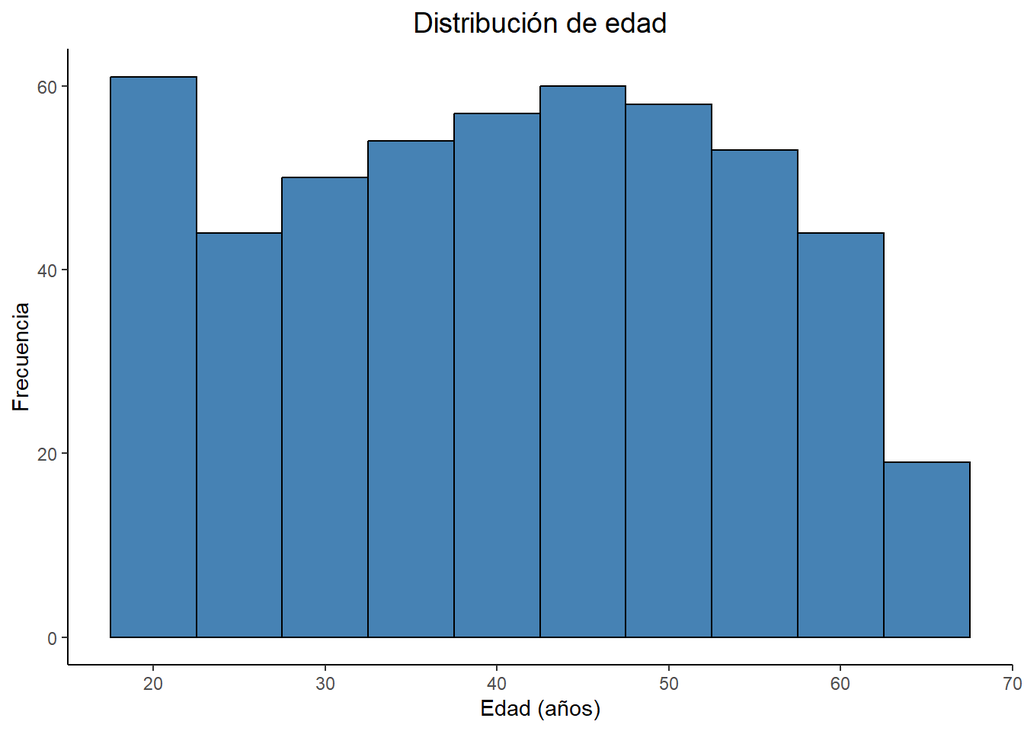

```r
library(ggplot2)
# gráfico de histograma para edad
ggplot(data, aes(x = age)) +
  geom_histogram(binwidth = 5, fill = "steelblue",color = "black", alpha = 1.2) +
   labs(title = "Distribución de edad",
       x = "Edad (años)",
       y = "Frecuencia") +
  theme_classic() +
  theme(
    plot.title = element_text(hjust = 0.5, size = 14)
  )
```

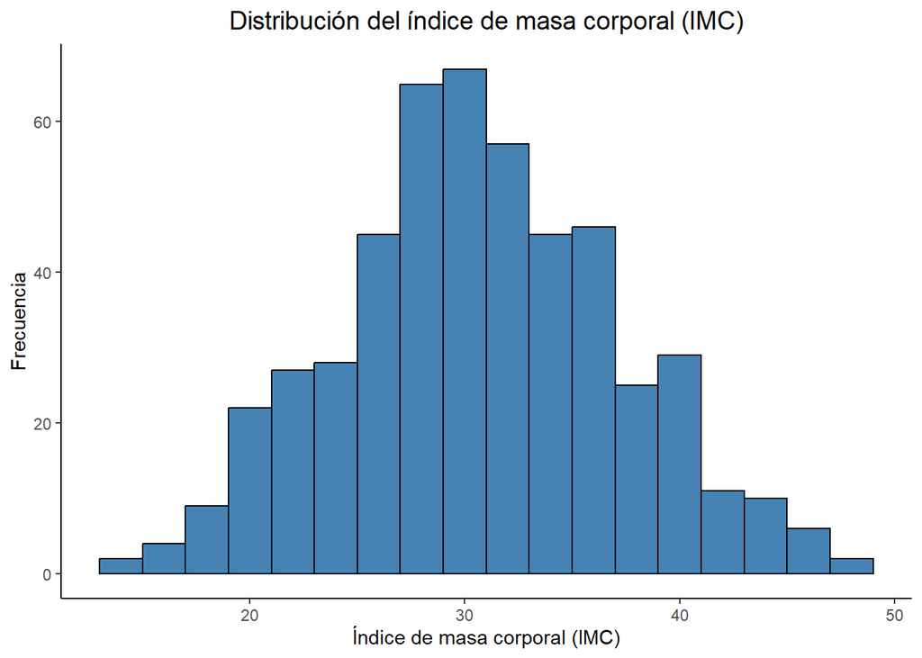

```r
# gráfico de histograma para IMC
ggplot(data, aes(x = bmi)) +
  geom_histogram(binwidth = 2, fill = "steelblue", color = "black", alpha = 1.2) +
  labs(
    title = "Distribución del índice de masa corporal (IMC)",
    x = "Índice de masa corporal (IMC)",
    y = "Frecuencia"
  ) +
  theme_classic() +
  theme(
    plot.title = element_text(hjust = 0.5, size = 14)
  )
```

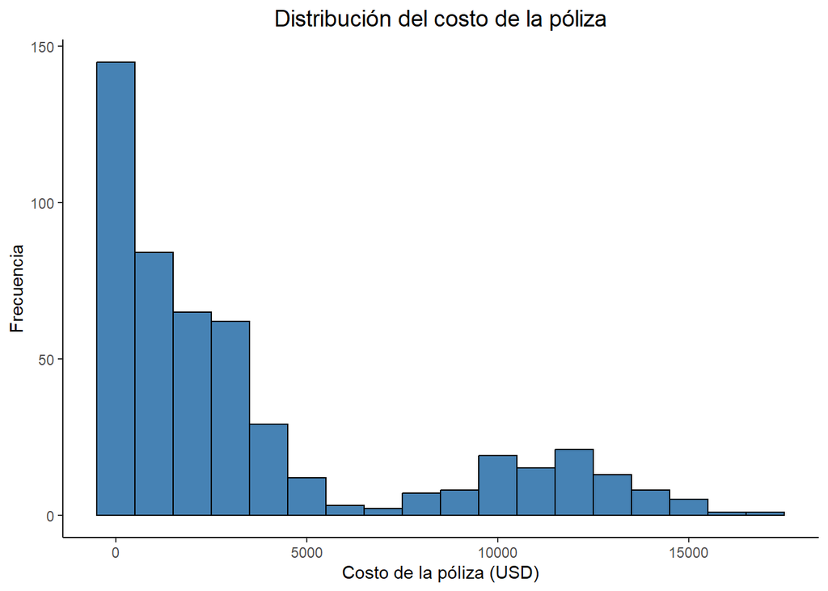

```r
# Gráfico de histograma para el costo de la póliza
ggplot(data, aes(x = charges)) +
  geom_histogram(binwidth = 1000, fill = "steelblue", color = "black", alpha = 1.2) +
  labs(
    title = "Distribución del costo de la póliza",
    x = "Costo de la póliza (USD)",
    y = "Frecuencia"
  ) +
  theme_classic() +
  theme(
    plot.title = element_text(hjust = 0.5, size = 14)
  )
```

#### 1.2 Boxplots por categoría

Comparación de `charges` según `smoker` y `region`:

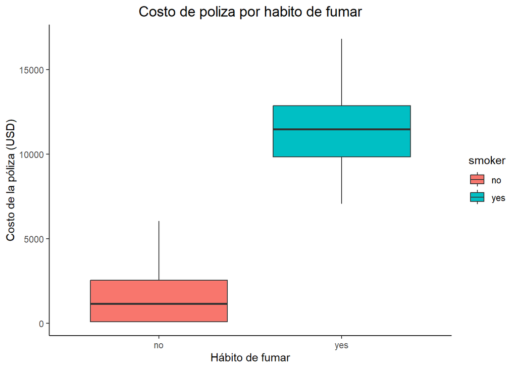

```r
# Boxplot de charges por smoker
ggplot(data, aes(x = smoker, y = charges,fill = smoker)) +
  geom_boxplot() +
     labs(title = "Costo de poliza por habito de fumar",
       x = "Hábito de fumar",
       y = "Costo de la póliza (USD)") +
  theme_classic() +
  theme(
    plot.title = element_text(hjust = 0.5, size = 14)
  )
```

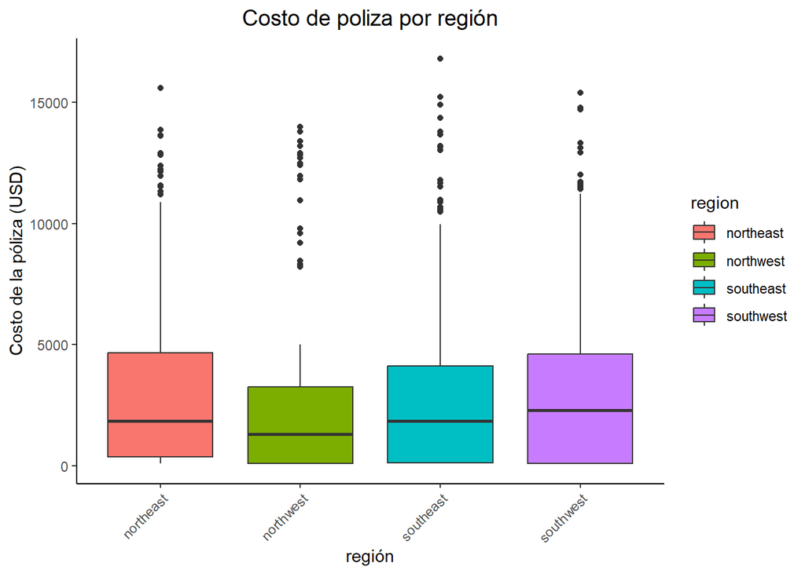

```r
# Boxplot de charges por region
ggplot(data, aes(x = region, y = charges,fill = region)) +
  geom_boxplot() +
     labs(title = "Costo de poliza por región",
       x = "región",
       y = "Costo de la póliza (USD)") +
  theme_classic() +
  theme(axis.text.x = element_text(angle = 45, hjust = 1)) +
  theme(
    plot.title = element_text(hjust = 0.5, size = 14)
  )
```

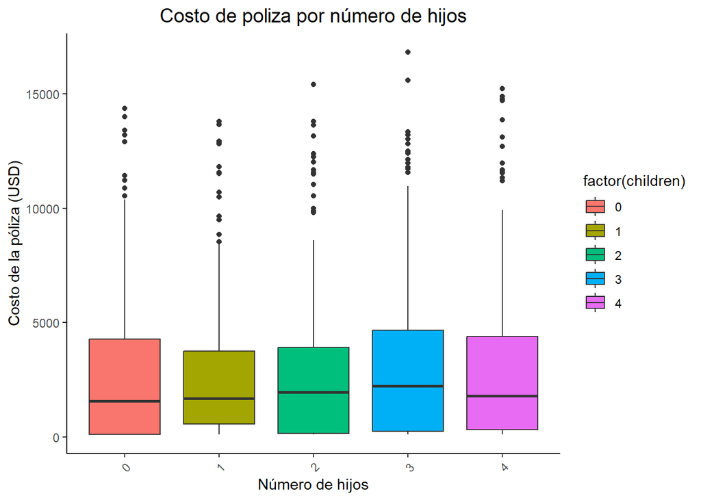

```r
# Boxplot de charges por número de hijos
ggplot(data, aes(x = children, y = charges,fill = factor(children))) +
  geom_boxplot() +
     labs(title = "Costo de poliza por número de hijos",
       x = "Número de hijos",
       y = "Costo de la póliza (USD)") +
  theme_classic() +
  theme(axis.text.x = element_text(angle = 45, hjust = 1)) +
  theme(
    plot.title = element_text(hjust = 0.5, size = 14)
  )
```

#### 1.3 Series temporales

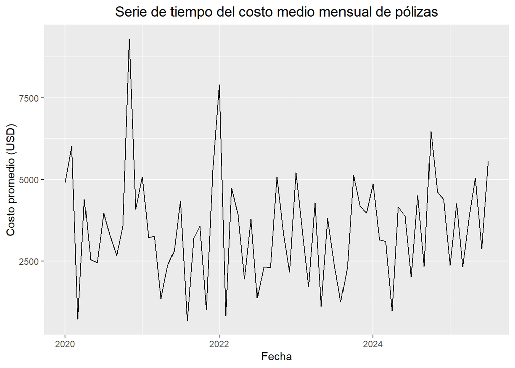

```r
#Transformar fecha
data$date <- as.Date(data$date)

# Serie temporal
data %>%
  mutate(year_month = floor_date(date, "month")) %>%
  group_by(year_month) %>%
  summarize(avg_charges = mean(charges)) %>%
  ggplot(aes(x = year_month, y = avg_charges)) +
  geom_line() +
  labs(title = "Serie de tiempo del costo medio mensual de pólizas", x = "Fecha", y = "Costo promedio (USD)") +
  theme(
    plot.title = element_text(hjust = 0.5, size = 14)
  )
```

### 2 Preprocesamiento

A continuación se prepara la data para modelado. Para esto, se convierten las variables categóricas a factores.

1. Codificación de variables categóricas

   ```r
   # Crear dummies para sex, smoker y region
   data$sex     <- factor(data$sex, levels=c("female","male"))
   data$smoker  <- factor(data$smoker, levels=c("no","yes"))
   data$region  <- factor(data$region)
   ```

2. Eliminamos `date`

   ```r
   library(dplyr)
   data <- data %>%
     dplyr::select(-any_of("date"))
   ```

3. Verificamos la estructura de la data para el modelado

   ```r
   # Verificar valores únicos y estructura actual
   str(data)
   ```

   ```
   ## 'data.frame':    500 obs. of  7 variables:
   ##  $ age     : int  20 35 42 59 48 20 57 63 41 49 ...
   ##  $ sex     : Factor w/ 2 levels "female","male": 1 1 2 1 1 2 2 2 1 2 ...
   ##  $ bmi     : num  36.5 27.6 20.1 34.2 31.4 40.9 20.8 46.8 39.6 29.9 ...
   ##  $ children: int  2 4 3 0 3 2 2 3 4 4 ...
   ##  $ smoker  : Factor w/ 2 levels "no","yes": 1 1 1 1 1 1 1 1 2 1 ...
   ##  $ region  : Factor w/ 4 levels "northeast","northwest",..: 4 4 3 3 3 1 4 2 3 2 ...
   ##  $ charges : num  3189 4794 100 172 4060 ...
   ```

   ```r
   lapply(data[c("sex", "smoker", "region")], levels)
   ```

   ```
   ## $sex
   ## [1] "female" "male"
   ##
   ## $smoker
   ## [1] "no"  "yes"
   ##
   ## $region
   ## [1] "northeast" "northwest" "southeast" "southwest"
   ```

### 3 Modelado y validación de supuestos (modelo original)

Se ajusta un modelo de regresión lineal múltiple con `charges` como variable dependiente y todas las demás como independientes o explicativas. Se incluyen efectos por categoría en `sex`, `smoker` y `region` mediante el uso de variables dummy (factoriales).

#### 3.1 Modelado

```r
# Ajuste del modelo de regresión lineal
modelo <- lm(charges ~ age + bmi + smoker + sex + children + region, data = data)
summary(modelo)
```

```
##
## Call:
## lm(formula = charges ~ age + bmi + smoker + sex + children +
##     region, data = data)
##
## Residuals:
##     Min      1Q  Median      3Q     Max
## -3777.5 -1226.6  -267.4  1091.0  5280.0
##
## Coefficients:
##                 Estimate Std. Error t value Pr(>|t|)
## (Intercept)      275.233    453.600   0.607  0.54428
## age                8.943      5.293   1.690  0.09174 .
## bmi               14.724     10.947   1.345  0.17923
## smokeryes       9826.499    176.374  55.714  < 2e-16 ***
## sexmale           59.336    141.155   0.420  0.67441
## children         163.142     49.420   3.301  0.00103 **
## regionnorthwest  -24.221    201.010  -0.120  0.90414
## regionsoutheast   94.081    193.026   0.487  0.62619
## regionsouthwest  168.467    198.784   0.847  0.39714
## ---
## Signif. codes:  0 '***' 0.001 '**' 0.01 '*' 0.05 '.' 0.1 ' ' 1
##
## Residual standard error: 1572 on 491 degrees of freedom
## Multiple R-squared:  0.8642, Adjusted R-squared:  0.862
## F-statistic: 390.6 on 8 and 491 DF,  p-value: < 2.2e-16
```

#### 3.2 Validación de supuestos

En esta sección comprobamos los supuestos clásicos de la regresión lineal múltiple sobre el modelo ajustado:

##### 3.2.1 Normalidad de residuos

```r
# Extraer residuos
residuos <- resid(modelo)

# Test de Shapiro–Wilk
shapiro.test(residuos)
```

```
##
##  Shapiro-Wilk normality test
##
## data:  residuos
## W = 0.96411, p-value = 1.061e-09
```

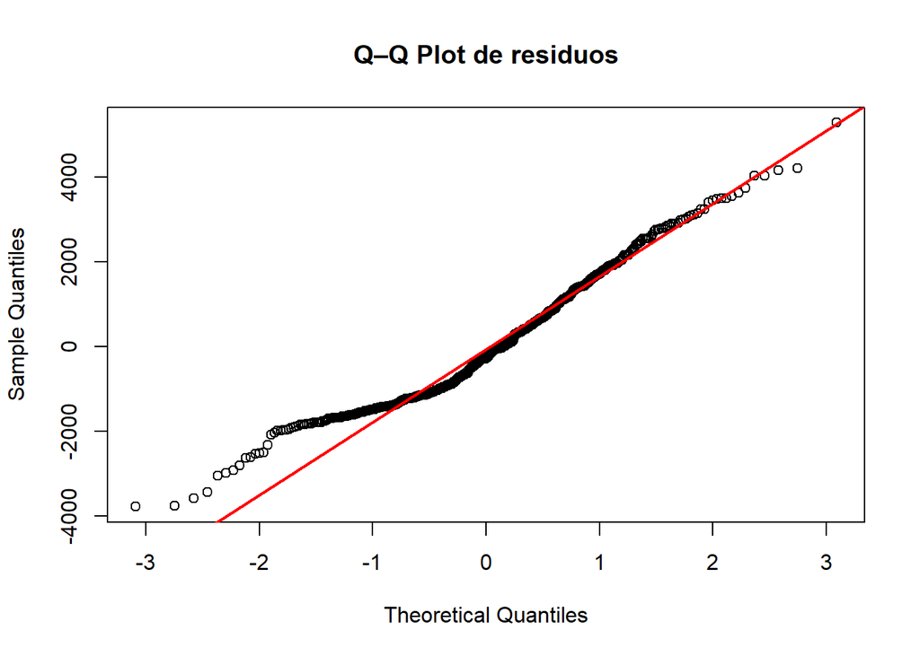

```r
# Gráfico Q–Q
qqnorm(residuos, main = "Q–Q Plot de residuos")
qqline(residuos, col = "red", lwd = 2)
```

##### 3.2.2 Homocedasticidad

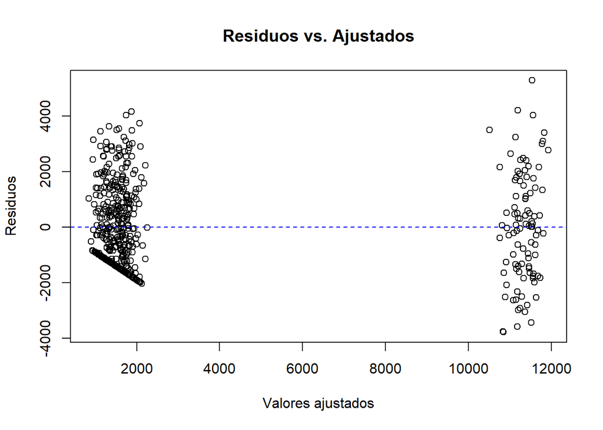

```r
# Residuos vs. valores ajustados
plot(modelo$fitted.values, residuos,
     xlab = "Valores ajustados",
     ylab = "Residuos",
     main = "Residuos vs. Ajustados")
abline(h = 0, lty = 2, col = "blue")
```

```r
# Test de Breusch–Pagan
library(lmtest)
bptest(modelo)
```

```
##
##  studentized Breusch-Pagan test
##
## data:  modelo
## BP = 30.949, df = 8, p-value = 0.0001435
```

##### 3.2.3 Multicolinealidad

```r
# Cálculo de VIF
library(car)
vif(modelo)
```

```
##              GVIF Df GVIF^(1/(2*Df))
## age      1.004554  1        1.002275
## bmi      1.008145  1        1.004064
## smoker   1.006544  1        1.003267
## sex      1.005389  1        1.002691
## children 1.004457  1        1.002226
## region   1.008270  3        1.001374
```

### 4 Modelado y validación de supuestos (modelo logarítmico)

Dado que el modelo original no cumplió con algunos de los supuestos fundamentales de la regresión lineal (especialmente la normalidad y homocedasticidad de los residuos), se ajusta un modelo de regresión lineal múltiple con `log(charges)` como variable dependiente y todas las demás columnas disponibles como variables independientes. Las variables categóricas (sex, smoker y region) se incluyen mediante codificación factorial (variables dummy), permitiendo modelar sus efectos de manera adecuada.

Esta transformación es útil cuando la variable respuesta presenta una distribución asimétrica o una varianza no constante.

#### 4.1 Modelado

```r
# Ajuste del modelo de regresión lineal con log(charges)
modelo_log <- lm(log(charges) ~ age + sex + bmi + children + smoker + region, data)
summary(modelo_log)
```

```
##
## Call:
## lm(formula = log(charges) ~ age + sex + bmi + children + smoker +
##     region, data = data)
##
## Residuals:
##    Min     1Q Median     3Q    Max
## -2.355 -1.573  0.188  1.105  2.101
##
## Coefficients:
##                  Estimate Std. Error t value Pr(>|t|)
## (Intercept)      5.910598   0.379000  15.595   <2e-16 ***
## age              0.008677   0.004422   1.962   0.0503 .
## sexmale          0.031710   0.117940   0.269   0.7881
## bmi              0.005422   0.009147   0.593   0.5536
## children         0.073012   0.041293   1.768   0.0777 .
## smokeryes        2.772757   0.147367  18.815   <2e-16 ***
## regionnorthwest -0.120632   0.167952  -0.718   0.4729
## regionsoutheast -0.039327   0.161281  -0.244   0.8075
## regionsouthwest -0.022243   0.166091  -0.134   0.8935
## ---
## Signif. codes:  0 '***' 0.001 '**' 0.01 '*' 0.05 '.' 0.1 ' ' 1
##
## Residual standard error: 1.314 on 491 degrees of freedom
## Multiple R-squared:  0.4241, Adjusted R-squared:  0.4147
## F-statistic:  45.2 on 8 and 491 DF,  p-value: < 2.2e-16
```

#### 4.2 Validación de supuestos

En esta sección se validan los supuestos clásicos de la regresión lineal aplicados al modelo logarítmico:

##### 4.2.1 Normalidad de residuos

```r
# Extraer residuos
residuos_log <- resid(modelo_log)

# Test de Shapiro–Wilk para normalidad
shapiro.test(residuos_log)
```

```
##
##  Shapiro-Wilk normality test
##
## data:  residuos_log
## W = 0.91243, p-value < 2.2e-16
```

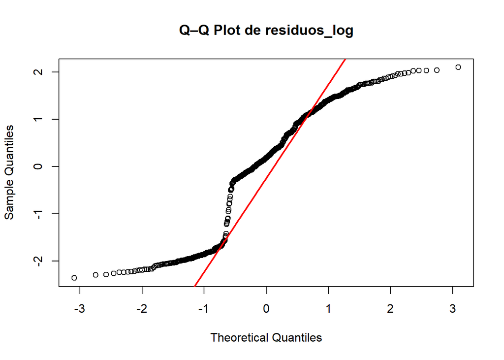

```r
# Gráfico Q–Q
qqnorm(residuos_log, main = "Q–Q Plot de residuos_log")
qqline(residuos_log, col = "red", lwd = 2)
```

##### 4.2.2 Homocedasticidad

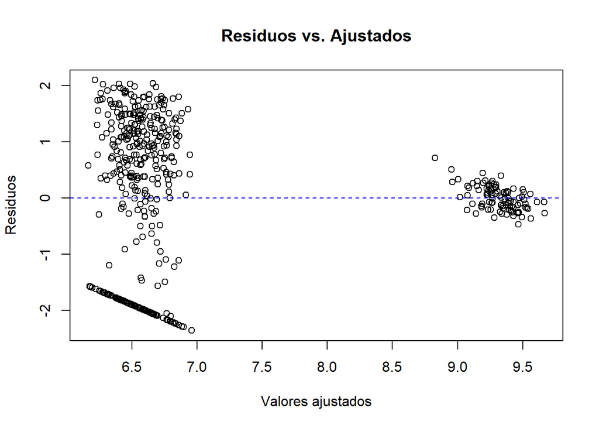

```r
# Gráfico de residuos vs. valores ajustados
plot(modelo_log$fitted.values, residuos_log,
     xlab = "Valores ajustados",
     ylab = "Residuos",
     main = "Residuos vs. Ajustados")
abline(h = 0, lty = 2, col = "blue")
```

```r
# Test de Breusch–Pagan
library(lmtest)
bptest(modelo_log)
```

```
##
##  studentized Breusch-Pagan test
##
## data:  modelo_log
## BP = 141.04, df = 8, p-value < 2.2e-16
```

##### 4.2.3 Multicolinealidad

```r
# Cálculo del VIF
library(car)
vif(modelo_log)
```

```
##              GVIF Df GVIF^(1/(2*Df))
## age      1.004554  1        1.002275
## sex      1.005389  1        1.002691
## bmi      1.008145  1        1.004064
## children 1.004457  1        1.002226
## smoker   1.006544  1        1.003267
## region   1.008270  3        1.001374
```

#### 4.3 Ajuste del modelo con errores robustos

Debido a la posible presencia de heterocedasticidad persistente, se estima nuevamente el modelo logarítmico utilizando errores estándar robustos mediante el estimador de White (sandwich estimator).

```r
library(sandwich)
library(lmtest)

coeftest(modelo_log, vcov = vcovHC(modelo_log, type = "HC1"))
```

```
##
## t test of coefficients:
##
##                   Estimate Std. Error t value Pr(>|t|)
## (Intercept)      5.9105976  0.3847195 15.3634  < 2e-16 ***
## age              0.0086769  0.0044862  1.9341  0.05367 .
## sexmale          0.0317105  0.1175632  0.2697  0.78748
## bmi              0.0054224  0.0092360  0.5871  0.55741
## children         0.0730124  0.0414387  1.7619  0.07870 .
## smokeryes        2.7727572  0.0772901 35.8747  < 2e-16 ***
## regionnorthwest -0.1206319  0.1657550 -0.7278  0.46710
## regionsoutheast -0.0393271  0.1581188 -0.2487  0.80368
## regionsouthwest -0.0222431  0.1641926 -0.1355  0.89230
## ---
## Signif. codes:  0 '***' 0.001 '**' 0.01 '*' 0.05 '.' 0.1 ' ' 1
```

### 5 Modelos alternativos: Regresión robusta y GLM

#### 5.1 Regresión robusta

La regresión robusta se basa en el uso de estimadores M que reducen la influencia de observaciones extremas en los coeficientes. Es especialmente útil cuando los residuos presentan valores atípicos o la distribución no es normal.

```r
library(MASS)

modelo_robusto <- rlm(log(charges) ~ age + sex + bmi + children + smoker + region, data = data)
summary(modelo_robusto)
```

```
##
## Call: rlm(formula = log(charges) ~ age + sex + bmi + children + smoker +
##     region, data = data)
## Residuals:
##     Min      1Q  Median      3Q     Max
## -2.3569 -1.5721  0.1883  1.1039  2.1016
##
## Coefficients:
##                 Value   Std. Error t value
## (Intercept)      5.9092  0.3805    15.5318
## age              0.0087  0.0044     1.9591
## sexmale          0.0320  0.1184     0.2707
## bmi              0.0054  0.0092     0.5929
## children         0.0732  0.0415     1.7651
## smokeryes        2.7726  0.1479    18.7418
## regionnorthwest -0.1212  0.1686    -0.7188
## regionsoutheast -0.0398  0.1619    -0.2460
## regionsouthwest -0.0228  0.1667    -0.1367
##
## Residual standard error: 1.698 on 491 degrees of freedom
```

#### 5.2 Modelo Lineal Generalizado (GLM)

El modelo GLM permite una especificación flexible al asumir que la variable respuesta sigue una distribución de la familia exponencial. Se utiliza una función de enlace logarítmica para modelar la media condicional de `charges`.

```r
modelo_glm <- glm(charges ~ age + bmi + smoker + sex + children + region,
                  family = Gamma(link = "log"), data = data)
summary(modelo_glm)
```

```
##
## Call:
## glm(formula = charges ~ age + bmi + smoker + sex + children +
##     region, family = Gamma(link = "log"), data = data)
##
## Coefficients:
##                  Estimate Std. Error t value Pr(>|t|)
## (Intercept)      6.789296   0.247349  27.448   <2e-16 ***
## age              0.006362   0.002886   2.204   0.0280 *
## bmi              0.003228   0.005969   0.541   0.5889
## smokeryes        2.028836   0.096177  21.095   <2e-16 ***
## sexmale          0.048962   0.076972   0.636   0.5250
## children         0.062334   0.026949   2.313   0.0211 *
## regionnorthwest -0.047356   0.109611  -0.432   0.6659
## regionsoutheast  0.027379   0.105258   0.260   0.7949
## regionsouthwest  0.075138   0.108397   0.693   0.4885
## ---
## Signif. codes:  0 '***' 0.001 '**' 0.01 '*' 0.05 '.' 0.1 ' ' 1
##
## (Dispersion parameter for Gamma family taken to be 0.7351897)
##
##     Null deviance: 1047.45  on 499  degrees of freedom
## Residual deviance:  613.02  on 491  degrees of freedom
## AIC: 8748
##
## Number of Fisher Scoring iterations: 7
```

Evaluación de GLM (Gamma con enlace log)

```r
# Devianza residual y AIC
summary(modelo_glm)$deviance
```

```
## [1] 613.0232
```

```r
AIC(modelo_glm)
```

```
## [1] 8748.007
```

### 6 Validación predictiva

Para evaluar la capacidad predictiva de los modelos estimados, se realiza una validación cruzada simple. Se divide el conjunto de datos en:

- **Entrenamiento (70%)**
- **Prueba (30%)**

#### 6.1 División de datos

```r
set.seed(123)  # Para reproducibilidad
indices <- sample(1:nrow(data), 0.7 * nrow(data))
train <- data[indices, ]
test <- data[-indices, ]
```

#### 6.2 Modelo original (regresión lineal)

```r
model_ols <- lm(charges ~ age + sex + bmi + children + smoker + region, data = train)
pred_ols <- predict(model_ols, newdata = test)

SSE_ols <- sum((test$charges - pred_ols)^2)
SST_ols <- sum((test$charges - mean(test$charges))^2)
R2_ols <- 1 - SSE_ols/SST_ols
R2_ols
```

```
## [1] 0.8776309
```

#### 6.3 Modelo logarítmico

```r
model_log <- lm(log(charges) ~ age + sex + bmi + children + smoker + region, data = train)
log_pred <- predict(model_log, newdata = test)
pred_log <- exp(log_pred)

SSE_log <- sum((test$charges - pred_log)^2)
SST_log <- sum((test$charges - mean(test$charges))^2)
R2_log <- 1 - SSE_log/SST_log
R2_log
```

```
## [1] 0.7984601
```

#### 6.4 Modelo robusto

```r
library(MASS)
model_rob <- rlm(log(charges) ~ age + sex + bmi + children + smoker + region, data = train)
log_pred_rob <- predict(model_rob, newdata = test)
pred_rob <- exp(log_pred_rob)

SSE_rob <- sum((test$charges - pred_rob)^2)
SST_rob <- sum((test$charges - mean(test$charges))^2)
R2_rob <- 1 - SSE_rob/SST_rob
R2_rob
```

```
## [1] 0.7898546
```

#### 6.5 Modelo GLM (distribución gamma, función log)

```r
model_glm <- glm(charges ~ age + bmi + smoker + sex + children + region,
                  family = Gamma(link = "log"), data = train)
pred_glm <- predict(model_glm, newdata = test, type = "response")

SSE_glm <- sum((test$charges - pred_glm)^2)
SST_glm <- sum((test$charges - mean(test$charges))^2)
R2_glm <- 1 - SSE_glm/SST_glm
R2_glm
```

```
## [1] 0.8443509
```

### 7 Interpretación de resultados

#### 7.1 Exploratory Data Analysis (EDA)

##### 7.1.3 Series temporales

La serie mensual del costo promedio de póliza entre enero 2020 y julio 2025 exhibe alta volatilidad. Destacan picos notables en noviembre 2020 (9 307 USD) y enero 2022 (7 906 USD), alternados con mínimos en marzo 2020 (727 USD) y abril 2024 (973 USD). Entre 2023 y mediados de 2025 persiste la alternancia de meses “baratos” y “caros”, aunque con una tendencia leve al alza al cerrar julio 2025 en 5 575 USD. Este comportamiento sugiere influencias estacionales, cambios en la composición de la cartera y ajustes periódicos de tarifas.

Nota: Se convirtieron las variables `sex`, `smoker` y `region` a tipo factor para el modelado, y se eliminó la columna `date` al no usarla como predictor. Así se garantiza que el empaquetado de dummies y la estructura del dataframe sean adecuados para la regresión.

#### 7.2 Modelo original

El modelo lineal explica el 86 % de la variabilidad en los costos de póliza, lo cual indica un buen ajuste general. El tabaquismo destaca como el factor más influyente, elevando el costo en casi 10 000 USD en promedio, con alta significancia estadística. También se encuentra un efecto positivo del número de hijos, aunque de menor magnitud. Otras variables como edad, IMC, sexo y región no resultaron significativas, lo cual sugiere que su impacto podría estar contenido en otros factores o requerir modelamiento no lineal.

Sin embargo, se detectaron violaciones a los supuestos clásicos. Los residuos no siguen una distribución normal (p < 0.001) y presentan colas pesadas según el Q–Q plot. Además, existe heterocedasticidad (p < 0.001 en el test de Breusch-Pagan), observada como mayor dispersión de residuos en pólizas costosas. En contraste, no se detecta multicolinealidad entre los predictores (GVIF ≈ 1). Estas observaciones sugieren la necesidad de transformar la variable dependiente o aplicar métodos robustos en secciones posteriores.

#### 7.4 Modelos alternativos

Como complemento al modelo logarítmico clásico, se aplicaron dos enfoques alternativos para evaluar la estabilidad de los resultados frente a valores atípicos o violaciones de supuestos clásicos. La regresión robusta, basada en estimadores M, ajusta los coeficientes reduciendo el peso de observaciones extremas, mientras que el modelo lineal generalizado (GLM) con familia Gamma y enlace log se adapta a distribuciones asimétricas y varianza no constante, sin requerir transformación previa de la variable dependiente.

##### 7.4.1 Regresión robusta

En la regresión robusta, los coeficientes resultaron prácticamente idénticos a los del modelo logarítmico clásico, lo que sugiere que los valores atípicos no influyeron excesivamente en el ajuste. El coeficiente de fumador se mantiene como el más significativo (2.77), equivalente a un aumento de casi 16 veces en el costo esperado. Edad (0.87 % por año) y número de hijos (7.6% por hijo) también siguen mostrando efectos marginalmente significativos. Este modelo es particularmente útil cuando persisten outliers o se sospecha que las inferencias por OLS pueden ser distorsionadas.

##### 7.4.2 Modelo Lineal Generalizado Gamma

El modelo GLM Gamma con enlace logarítmico ofrece una especificación más realista del proceso generador de los datos, al modelar directamente la media de los costos sin asumir normalidad ni homocedasticidad. Aquí también se confirma el rol predominante del tabaquismo (coeficiente ≈ 2.03; p < 0.001), así como los efectos positivos de edad y children, aunque ligeramente atenuados. El AIC obtenido (8748) y la reducción sustancial en la devianza (de 1047 a 613) indican un buen ajuste bajo esta familia. En conjunto, tanto la regresión robusta como el GLM Gamma consolidan la robustez de los hallazgos obtenidos previamente y confirman que el tabaquismo es el principal determinante del costo médico, incluso bajo supuestos más flexibles.

#### 7.5 Validación predictiva

La comparación de los cuatro modelos en datos no vistos revela que la regresión lineal clásica (OLS) obtuvo el mayor R² en prueba (≈ 0.8776), lo cual indica que, sin transformación, captura con precisión la variabilidad de los costos en el conjunto de prueba. Sin embargo, este modelo ya se demostró impropio para inferencias fiables debido a la violación de supuestos de normalidad y homocedasticidad en los residuos.

Por su parte, el GLM Gamma con enlace log logra un R² intermedio (≈ 0.8444) al modelar directamente la variable original sin requerir transformación previa. Este resultado demuestra que el GLM ofrece un buen balance entre ajuste predictivo y cumplimiento de supuestos (al usar la familia Gamma), consolidándose como la especificación recomendada cuando se busca robustez frente a asimetría y heterocedasticidad.

## Resultados

### 1 Resumen del modelo final (GLM Gamma‑log)

A continuación se presenta el resumen de coeficientes y las métricas de ajuste para el modelo lineal generalizado con familia Gamma y enlace logarítmico, considerado como especificación final:

```r
summary(modelo_glm)
```

```
##
## Call:
## glm(formula = charges ~ age + bmi + smoker + sex + children +
##     region, family = Gamma(link = "log"), data = data)
##
## Coefficients:
##                  Estimate Std. Error t value Pr(>|t|)
## (Intercept)      6.789296   0.247349  27.448   <2e-16 ***
## age              0.006362   0.002886   2.204   0.0280 *
## bmi              0.003228   0.005969   0.541   0.5889
## smokeryes        2.028836   0.096177  21.095   <2e-16 ***
## sexmale          0.048962   0.076972   0.636   0.5250
## children         0.062334   0.026949   2.313   0.0211 *
## regionnorthwest -0.047356   0.109611  -0.432   0.6659
## regionsoutheast  0.027379   0.105258   0.260   0.7949
## regionsouthwest  0.075138   0.108397   0.693   0.4885
## ---
## Signif. codes:  0 '***' 0.001 '**' 0.01 '*' 0.05 '.' 0.1 ' ' 1
##
## (Dispersion parameter for Gamma family taken to be 0.7351897)
##
##     Null deviance: 1047.45  on 499  degrees of freedom
## Residual deviance:  613.02  on 491  degrees of freedom
## AIC: 8748
##
## Number of Fisher Scoring iterations: 7
```

- **Deviance residual:** 613.02
- **AIC:** 8748.01
- **Pseudo‑R² en datos de entrenamiento:** No aplica directamente en GLM, pero el modelo muestra una reducción de deviance significativa (de 1047.45 a 613.02).

### 2 Comparación de desempeño predictivo

Se comparan los cuatro modelos en base al coeficiente de determinación R² calculado sobre el conjunto de prueba (30 % de los datos):

| Modelo | R² en prueba |
| --- | --- |
| Regresión lineal (OLS) | 0.8776 |
| Regresión logarítmica (log-OLS) | 0.7985 |
| Regresión robusta | 0.7899 |
| Modelo GLM (Gamma log) | 0.8444 |

Estos resultados cuantitativos permiten visualizar claramente que, aunque la regresión OLS pura alcanza el mayor R², el GLM Gamma‑log combina un ajuste predictivo competitivo con la adecuación estadística para datos asimétricos y heterocedásticos, razón por la cual se recomienda como modelo final en este estudio.

## Discusión

Al incorporar errores estándar robustos (White) al modelo logarítmico, se restauró la fiabilidad de las inferencias sin modificar los coeficientes: se conservaron los efectos principales y los niveles de significancia, pero las pruebas t e intervalos son ahora fiables aun en presencia de heterocedasticidad. La regresión robusta (RLM), basada en estimadores M, corroboró además que los outliers no alteraban los resultados esenciales, pues sus coeficientes coinciden prácticamente con los del modelo log‑OLS. Sin embargo, estos enfoques sacrifican parte del poder predictivo en favor de mayor solidez estadística.

Por su parte, el GLM Gamma‑log representa la mejor combinación práctica para pricing de seguros médicos. Con un R² de prueba de 0.8444, conserva un buen desempeño predictivo y, al modelar directamente la variable original, evita los sesgos de retransfórmación. La especificación Gamma‑log se adapta de forma natural a la asimetría y heterocedasticidad de los costos, garantizando inferencias más fiables sin necesidad de transformaciones ad hoc.

### 1 Implicaciones prácticas

- El coeficiente de “smokeryes” en el GLM (≈2.03) indica que, si las demás variables se mantienen constantes, la prima de un fumador es casi 8 veces mayor (`exp(2.03) ≈ 7.6`), dato clave para segmentar tarifas.
- Las elasticidades de edad (0.64 % por año) y children (6.43 % por dependiente) permiten ajustar incrementos de primas de forma porcentual, facilitando su aplicación en tablas de tarifas.
- Los hombres pagan en promedio un 5.02 % más que las mujeres , cada punto adicional de IMC incrementa la prima en 0.32 %, y las variaciones regionales son: Northwest, –4.62 %; Southeast, +2.78 %; Southwest, +7.80 %. Aunque no resulten estadísticamente significativos, estos ajustes permiten afinar las tarifas sin recurrir a segmentaciones geográficas complejas.
- Al evitar la retransformación de un modelo logarítmico, el GLM simplifica la puesta en producción de predicciones en dólares, sin necesidad de “exponenciar” valores.

### 2 Fortalezas y limitaciones

#### 1.1 Fortalezas

- Evaluación de múltiples modelos (OLS, log‑OLS, RLM, GLM) con validación de supuestos.
- Uso de transformaciones y estimaciones robustas para garantizar la fiabilidad de las inferencias.
- Comparación de desempeño predictivo en datos no vistos mediante R².

#### 1.2 Limitaciones

- Datos simulados, que pueden no capturar totalmente la complejidad de un mercado real.
- Ausencia de validación externa con datos de otra fuente.
- No se incluyeron variables clínicas o de estilo de vida que podrían mejorar el ajuste.

## Conclusiones y Recomendaciones

El análisis comparativo de los cuatro modelos confirma que el GLM Gamma‑log es la especificación más adecuada para estimar costos de pólizas médicas. Este modelo combina un rendimiento predictivo sólido (R² ≈ 0.8444) con una correcta gestión de la asimetría y la heterocedasticidad de los datos, evitando sesgos de retransformación y simplificando la producción de predicciones en dólares.

Dentro de esta especificación, el tabaquismo se mantiene como el factor de riesgo más crucial, con un promedio de casi 8 veces más que los no fumadores, mientras que la edad y el número de hijos ajustan la prima en 0.64 % y 6.43 % por unidad respectivamente. Variables como IMC, sexo y región no resultaron significativas tras controlar por estos factores; sin embargo, sus efectos menores pueden ser útiles para afinar tarifas de forma porcentual y evaluarse en futuros análisis con datos reales.

Recomendaciones prácticas